# DATA621 - Crime

Daniel Hong, Mauricio Alarcon, Maxwell Wagner

October 10, 2016

## 1. DATA EXPLORATION (25 Points)

Describe the size and the variables in the moneyball training data set. Consider that too much detail will cause a manager to lose interest while too little detail will make the manager consider that you aren’t doing your job. Some suggestions are given below. Please do NOT treat this as a check list of things to do to complete the assignment. You should have your own thoughts on what to tell the boss. These are just ideas.

1. Mean / Standard Deviation / Median

```r
require("plyr")
require("knitr")
require("psych")
# Let's load the data

training <- read.csv(url('https://raw.githubusercontent.com/rmalarc/DATA621/master/hw03/crime-training-data.csv'))
metadata <- read.csv(url('https://raw.githubusercontent.com/rmalarc/DATA621/master/hw03/crime-metadata.csv'))
evaluation <- read.csv(url('https://raw.githubusercontent.com/rmalarc/DATA621/master/hw03/crime-evaluation-data.csv'))

kable(metadata)
```

| Variable | Definiton | Type |
| --- | --- | --- |
| zn | proportion of residential land zoned for large lots (over 25000 square feet) | (predictor variable) |
| indus | proportion of non-retail business acres per suburb | (predictor variable) |
| chas | a dummy var. for whether the suburb borders the Charles River (1) or not (0) | (predictor variable) |
| nox | nitrogen oxides concentration (parts per 10 million) | (predictor variable) |
| rm | average number of rooms per dwelling | (predictor variable) |
| age | proportion of owner-occupied units built prior to 1940 | (predictor variable) |
| dis | weighted mean of distances to five Boston employment centers | (predictor variable) |
| rad | index of accessibility to radial highways | (predictor variable) |
| tax | full-value property-tax rate per $10,000 | (predictor variable) |
| ptratio | pupil-teacher ratio by town | (predictor variable) |
| black | 1000(Bk - 0.63)2 where Bk is the proportion of blacks by town | (predictor variable) |
| lstat | lower status of the population (percent) | (predictor variable) |
| medv | median value of owner-occupied homes in $1000s | (predictor variable) |
| target | whether the crime rate is above the median crime rate (1) or not (0) | (response variable) |

```r
columns <- colnames(training)
target <- "target"
inputs <- columns[!columns %in% c(target,"INDEX")]


summary <- describe(training[,c(target,inputs)])[,c("n","mean","sd","median","min","max")]
summary$completeness <- summary$n/nrow(training)
summary$cv <- 100*summary$sd/summary$mean

kable(summary)
```

|  | n | mean | sd | median | min | max | completeness | cv |
| --- | --- | --- | --- | --- | --- | --- | --- | --- |
| target | 466 | 0.4914163 | 0.5004636 | 0.00000 | 0.0000 | 1.0000 | 1 | 101.84106 |
| zn | 466 | 11.5772532 | 23.3646511 | 0.00000 | 0.0000 | 100.0000 | 1 | 201.81515 |
| indus | 466 | 11.1050215 | 6.8458549 | 9.69000 | 0.4600 | 27.7400 | 1 | 61.64648 |
| chas | 466 | 0.0708155 | 0.2567920 | 0.00000 | 0.0000 | 1.0000 | 1 | 362.62142 |
| nox | 466 | 0.5543105 | 0.1166667 | 0.53800 | 0.3890 | 0.8710 | 1 | 21.04717 |
| rm | 466 | 6.2906738 | 0.7048513 | 6.21000 | 3.8630 | 8.7800 | 1 | 11.20470 |
| age | 466 | 68.3675966 | 28.3213784 | 77.15000 | 2.9000 | 100.0000 | 1 | 41.42515 |
| dis | 466 | 3.7956929 | 2.1069496 | 3.19095 | 1.1296 | 12.1265 | 1 | 55.50896 |
| rad | 466 | 9.5300429 | 8.6859272 | 5.00000 | 1.0000 | 24.0000 | 1 | 91.14258 |
| tax | 466 | 409.5021459 | 167.9000887 | 334.50000 | 187.0000 | 711.0000 | 1 | 41.00103 |
| ptratio | 466 | 18.3984979 | 2.1968447 | 18.90000 | 12.6000 | 22.0000 | 1 | 11.94035 |
| black | 466 | 357.1201502 | 91.3211298 | 391.34000 | 0.3200 | 396.9000 | 1 | 25.57154 |
| lstat | 466 | 12.6314592 | 7.1018907 | 11.35000 | 1.7300 | 37.9700 | 1 | 56.22383 |
| medv | 466 | 22.5892704 | 9.2396814 | 21.20000 | 5.0000 | 50.0000 | 1 | 40.90297 |

2. Bar Chart or Box Plot of the data

### How are the input values distributed?, do we need to do something about them?

Here’s the distribution of the values for each of the variables

```r
require("reshape2")
```

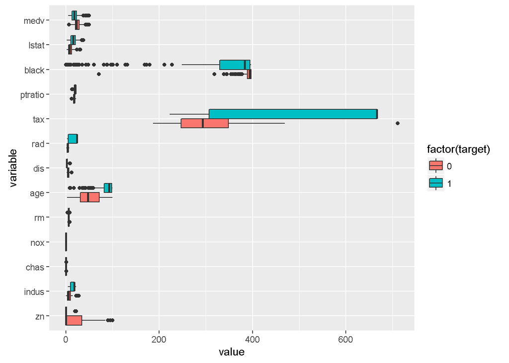

```r
require("ggplot2")
# Let's melt the DF so that we can plot it more easily

ggplot(melt(training, measure.vars = inputs)
       ,aes(x=variable,y=value)
       )+
    geom_boxplot(aes(fill = factor(target))) +
    coord_flip()
```

Let’s get a view of the normalized values:

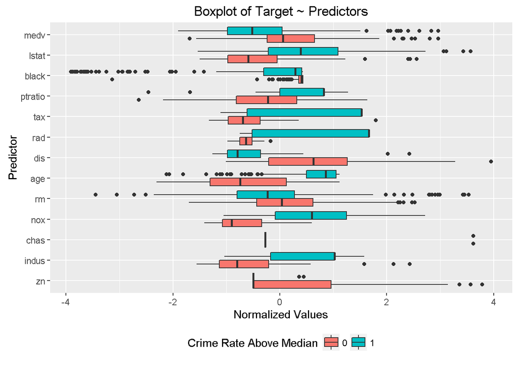

```r
require("reshape2")
require("ggplot2")
# Let's melt the DF so that we can plot it more easily

ggplot(melt(data.frame(scale(training[,inputs]),target=training[,target]), measure.vars = inputs),
       aes(x=variable,y=value)
       )+
    geom_boxplot(aes(fill = factor(target)))+
  guides(fill=guide_legend(title="Crime Rate Above Median")) +
   theme(legend.position="bottom")+
    coord_flip()+
  labs(title="Boxplot of Target ~ Predictors", y="Normalized Values", x="Predictor")
```

possible correlations

```r
training_normalized <- data.frame(scale(training[,inputs]),target=training[,target])

summary_positive <- describe(training_normalized[training_normalized$target==1,c(target,inputs)])[,c("mean","n")]
summary_negative <- describe(training_normalized[training_normalized$target==0,c(target,inputs)])[,c("mean","n")]
summary_by_target <- merge(summary_positive,summary_negative,by="row.names")
colnames(summary_by_target) <- c("Variable","CR Above Median - Avg","CR Above Median - n","CR Below Median - Avg", "CR Below Median - n")
summary_by_target$delta <- abs(summary_by_target[,"CR Above Median - Avg"]-summary_by_target[,"CR Below Median - Avg"])

kable(merge(metadata,summary_by_target)[order(-summary_by_target$delta),])
```

|  | Variable | Definiton | Type | CR Above Median - Avg | CR Above Median - n | CR Below Median - Avg | CR Below Median - n | delta |
| --- | --- | --- | --- | --- | --- | --- | --- | --- |
| 8 | nox | nitrogen oxides concentration (parts per 10 million) | (predictor variable) | 0.7378874 | 229 | -0.7129798 | 237 | 1.4508672 |
| 1 | age | proportion of owner-occupied units built prior to 1940 | (predictor variable) | 0.6403298 | 229 | -0.6187153 | 237 | 1.2590452 |
| 10 | rad | index of accessibility to radial highways | (predictor variable) | 0.6382960 | 229 | -0.6167502 | 237 | 1.2550462 |
| 4 | dis | weighted mean of distances to five Boston employment centers | (predictor variable) | -0.6287112 | 229 | 0.6074889 | 237 | 1.2362001 |
| 13 | tax | full-value property-tax rate per $10,000 | (predictor variable) | 0.6210287 | 229 | -0.6000657 | 237 | 1.2210945 |
| 5 | indus | proportion of non-retail business acres per suburb | (predictor variable) | 0.6146645 | 229 | -0.5939164 | 237 | 1.2085809 |
| 12 | target | whether the crime rate is above the median crime rate (1) or not (0) | (response variable) | 1.0000000 | 229 | 0.0000000 | 237 | 1.0000000 |
| 6 | lstat | lower status of the population (percent) | (predictor variable) | 0.4767387 | 229 | -0.4606462 | 237 | 0.9373849 |
| 14 | zn | proportion of residential land zoned for large lots (over 25000 square feet) | (predictor variable) | -0.4386859 | 229 | 0.4238779 | 237 | 0.8625638 |
| 2 | black | 1000(Bk - 0.63)2 where Bk is the proportion of blacks by town | (predictor variable) | -0.3586836 | 229 | 0.3465761 | 237 | 0.7052597 |
| 7 | medv | median value of owner-occupied homes in $1000s | (predictor variable) | -0.2749404 | 229 | 0.2656598 | 237 | 0.5406002 |
| 9 | ptratio | pupil-teacher ratio by town | (predictor variable) | 0.2549190 | 229 | -0.2463141 | 237 | 0.5012331 |
| 11 | rm | average number of rooms per dwelling | (predictor variable) | -0.1550285 | 229 | 0.1497955 | 237 | 0.3048241 |
| 3 | chas | a dummy var. for whether the suburb borders the Charles River (1) or not (0) | (predictor variable) | 0.0813406 | 229 | -0.0785949 | 237 | 0.1599355 |

## 2. DATA PREPARATION (25 Points)

Describe how you have transformed the data by changing the original variables or creating new variables. If you did transform the data or create new variables, discuss why you did this. Here are some possible transformations.

1. Fix missing values (maybe with a Mean or Median value)
2. Create flags to suggest if a variable was missing
3. Transform data by putting it into buckets
4. Mathematical transforms such as log or square root (or use Box-Cox)
5. Combine variables (such as ratios or adding or multiplying) to create new variables

```r
transformed <- training

cap <- function(x){
    quantiles <- c( qnorm(0.05,mean(x),sd(x)), qnorm(0.95,mean(x),sd(x)) )
    x[ x < quantiles[1] ] <- max(0,quantiles[1])
    x[ x > quantiles[2] ] <- quantiles[2]
    x
}

#transformed$black <- log(transformed$black)
transformed<-data.frame(apply( transformed[,inputs],2, cap),target=transformed$target)
```

split the dataset into training and testing

```r
## 75% of the sample size
smp_size <- floor(0.75 * nrow(transformed))

## set the seed to make your partition reproductible
set.seed(123)
train_ind <- c(sample(seq_len(nrow(transformed[transformed$target==1,])), size = smp_size/2),sample(seq_len(nrow(transformed[transformed$target==0,])), size = smp_size/2))

train <- transformed[train_ind, ]
test <- transformed[-train_ind, ]
```

```r
model <- glm(I(target)~.,data=train,family = binomial)

summary(model)
```

```
##
## Call:
## glm(formula = I(target) ~ ., family = binomial, data = train)
##
## Deviance Residuals:
##      Min        1Q    Median        3Q       Max
## -2.22410  -0.13042  -0.00395   0.00545   2.49364
##
## Coefficients:
##               Estimate Std. Error z value Pr(>|z|)
## (Intercept) -44.320332  10.723555  -4.133 3.58e-05 ***
## zn           -0.014421   0.041171  -0.350 0.726141
## indus        -0.045782   0.086818  -0.527 0.597959
## chas         -0.806872   1.924962  -0.419 0.675097
## nox          60.129524  12.628974   4.761 1.92e-06 ***
## rm           -0.300180   1.074714  -0.279 0.780006
## age           0.033357   0.020269   1.646 0.099816 .
## dis           0.609139   0.350246   1.739 0.082004 .
## rad           0.765734   0.206928   3.700 0.000215 ***
## tax          -0.008116   0.004029  -2.014 0.043993 *
## ptratio       0.561608   0.197659   2.841 0.004493 **
## black        -0.023973   0.011537  -2.078 0.037716 *
## lstat         0.066821   0.091633   0.729 0.465863
## medv          0.271531   0.118118   2.299 0.021515 *
## ---
## Signif. codes:  0 '***' 0.001 '**' 0.01 '*' 0.05 '.' 0.1 ' ' 1
##
## (Dispersion parameter for binomial family taken to be 1)
##
##     Null deviance: 481.50  on 347  degrees of freedom
## Residual deviance: 125.91  on 334  degrees of freedom
## AIC: 153.91
##
## Number of Fisher Scoring iterations: 9
```

```r
predicted <- predict(model,test,type='response')
require("pROC")
```

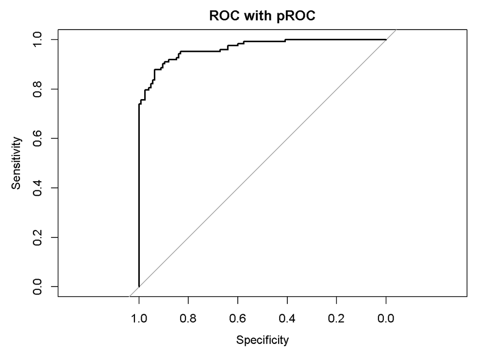

```
##
## Call:
## roc.default(response = ifelse(test$target > 0.5, 1, 0), predictor = predicted)
##
## Data: predicted in 125 controls (ifelse(test$target > 0.5, 1, 0) 0) < 123 cases (ifelse(test$target > 0.5, 1, 0) 1).
## Area under the curve: 0.9649
```

```r
d_roc <- roc(ifelse(test$target>0.5,1,0),predicted)
plot(d_roc, main = "ROC with pROC")
```

```r
#ci(d_roc)

require("caret")
table(ifelse(test$target>0.5,1,0),ifelse(predicted>0.5,1,0))
```

```
##
##       0   1
##   0 117   8
##   1  18 105
```

## 3. BUILD MODELS (25 Points)

Using the training data, build at least three different binary logistic regression models, using different variables (or the same variables with different transformations). You may select the variables manually, use an approach such as Forward or Stepwise, use a different approach, or use a combination of techniques. Describe the techniques you used. If you manually selected a variable for inclusion into the model or exclusion into the model, indicate why this was done.

Be sure to explain how you can make inferences from the model, as well as discuss other relevant model output. Discuss the coefficients in the models, do they make sense? Are you keeping the model even though it is counter intuitive? Why? The boss needs to know.

```r
valid_data <- transformed
predictors <- inputs[!inputs %in% c("indus","chas","lstat","rm","black","zn")]

model <- glm(I(target)~.,data=train[,c(predictors,target)],family = binomial)

summary(model)
```

```
##
## Call:
## glm(formula = I(target) ~ ., family = binomial, data = train[,
##     c(predictors, target)])
##
## Deviance Residuals:
##      Min        1Q    Median        3Q       Max
## -1.81652  -0.16500  -0.00849   0.00404   2.68018
##
## Coefficients:
##               Estimate Std. Error z value Pr(>|z|)
## (Intercept) -48.085247   9.414239  -5.108 3.26e-07 ***
## nox          56.208776  10.534838   5.336 9.53e-08 ***
## age           0.034477   0.014868   2.319 0.020407 *
## dis           0.489997   0.286398   1.711 0.087100 .
## rad           0.745392   0.192047   3.881 0.000104 ***
## tax          -0.007141   0.003124  -2.286 0.022266 *
## ptratio       0.422802   0.141278   2.993 0.002765 **
## medv          0.174909   0.057124   3.062 0.002199 **
## ---
## Signif. codes:  0 '***' 0.001 '**' 0.01 '*' 0.05 '.' 0.1 ' ' 1
##
## (Dispersion parameter for binomial family taken to be 1)
##
##     Null deviance: 481.50  on 347  degrees of freedom
## Residual deviance: 133.95  on 340  degrees of freedom
## AIC: 149.95
##
## Number of Fisher Scoring iterations: 9
```

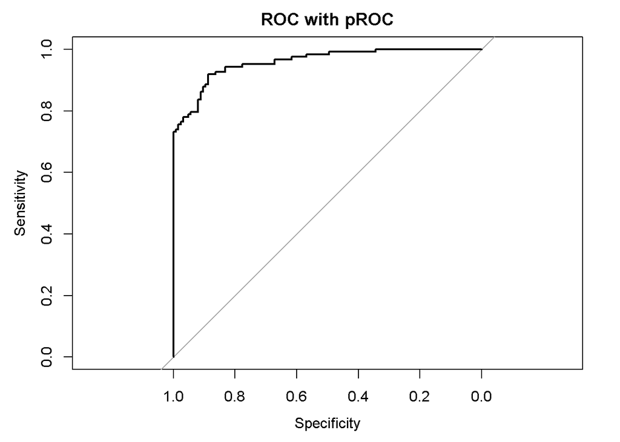

```
##
## Call:
## roc.default(response = test$target, predictor = predicted)
##
## Data: predicted in 125 controls (test$target 0) < 123 cases (test$target 1).
## Area under the curve: 0.9596
```

```r
predicted <- predict(model,test,type='response')
require("pROC")
d_roc <- roc(test$target,predicted)
plot(d_roc, main = "ROC with pROC")
```

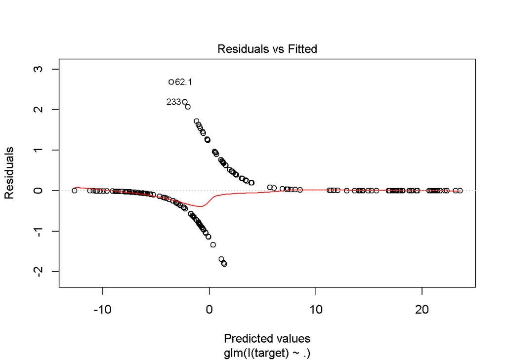

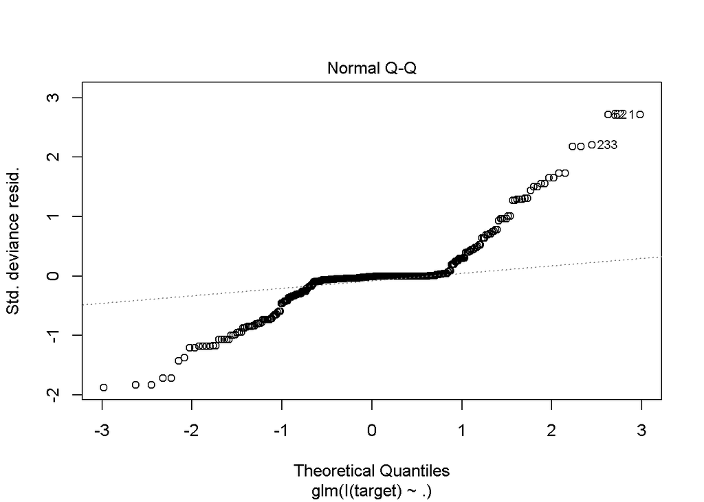

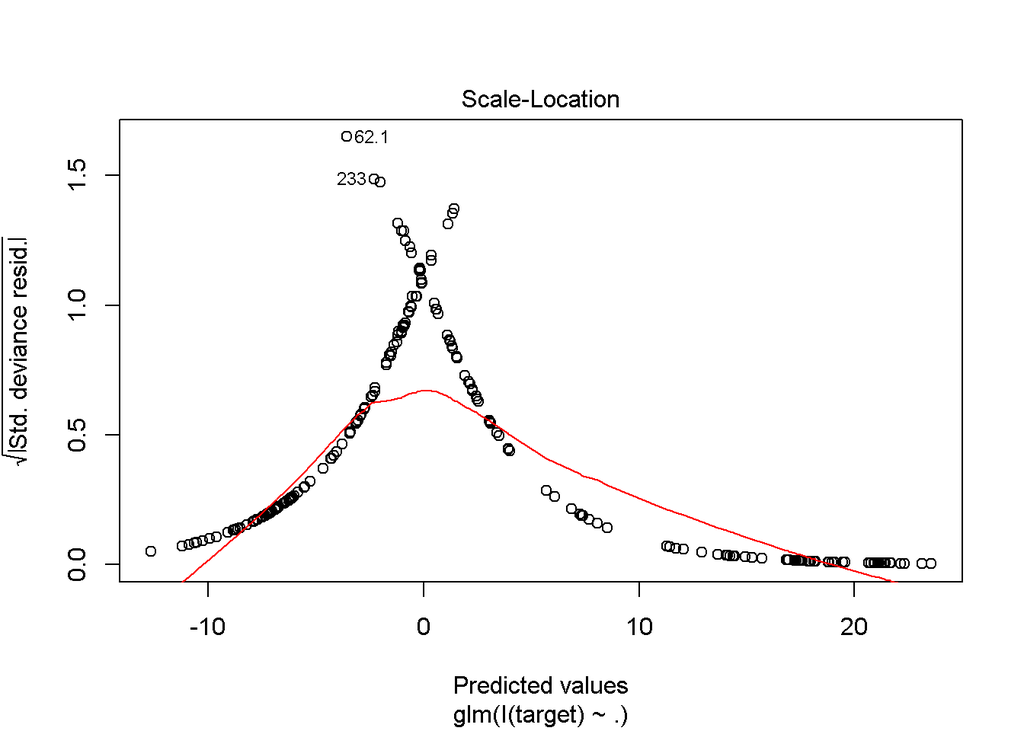

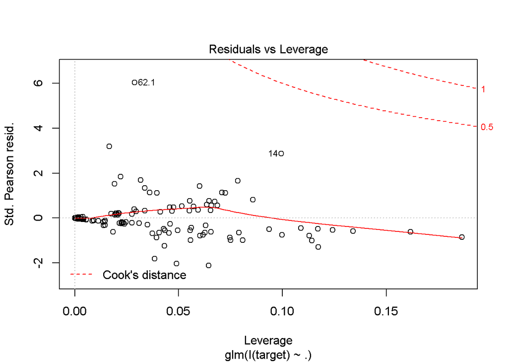

```r
#ci(d_roc)



plot(model)
```

```r
require("caret")
table(test$target,ifelse(predicted>0.5,1,0))
```

```
##
##       0   1
##   0 115  10
##   1  23 100
```

```r
d<- data.frame(class=test$target,scored.class=ifelse(predicted>0.5,1,0))

# let's use this helper function that will return all the rates for future calculations
confusion_matrix <- function(d){
  data.frame(tp=nrow(d[d$class==1 & d$scored.class==1,]),
             tn=nrow(d[d$class==0 & d$scored.class==0,]),
             fp=nrow(d[d$class==0 & d$scored.class==1,]),
             fn=nrow(d[d$class==1 & d$scored.class==0,])
  )
}

confusion_matrix(d)
```

```
##    tp  tn fp fn
## 1 100 115 10 23
```

```r
accuracy<-function(d){
  f <- confusion_matrix(d)
  (f$tp+f$tn)/(f$tp+f$fp+f$tn+f$fn)
}
accuracy(d)
```

```
## [1] 0.8669355
```

```r
classification_error_rate<-function(d){
  f <- confusion_matrix(d)
  (f$fp+f$fn)/(f$tp+f$fp+f$tn+f$fn)
}
classification_error_rate(d)
```

```
## [1] 0.1330645
```

```r
precision_c<-function(d){
  f <- confusion_matrix(d)
  (f$tp)/(f$tp+f$fp)
}
precision_c(d)
```

```
## [1] 0.9090909
```

```r
sensitivity_c<-function(d){
  f <- confusion_matrix(d)
  (f$tp)/(f$tp+f$fn)
}
sensitivity_c(d)
```

```
## [1] 0.8130081
```

```r
specificity_c<-function(d){
  f <- confusion_matrix(d)
  (f$tn)/(f$tn+f$fp)
}
specificity_c(d)
```

```
## [1] 0.92
```

```r
f1_score<-function(d){
  p<- precision_c(d)
  s<- sensitivity_c(d)
  2*p*s/(p+s)
}
f1_score(d)
```

```
## [1] 0.8583691
```

## 4. SELECT MODELS (25 Points)

Decide on the criteria for selecting the best binary logistic regression model. Will you select models with slightly worse performance if it makes more sense or is more parsimonious? Discuss why you selected your models.

For the binary logistic regression model, will you use a metric such as log likelihood, AIC, ROC curve, etc.? Using the training data set, evaluate the binary logistic regression model based on (a) accuracy, (b) classification error rate, (c) precision, (d) sensitivity, (e) specificity, (f) F1 score, (g) AUC, and (h) confusion matrix. Make predictions using the evaluation data set.

# Predictions

```r
mean_sd <- function(x){
  c( qnorm(0.05,mean(x),sd(x)), qnorm(0.95,mean(x),sd(x)) )
}


trans_params<-data.frame(apply( transformed[,inputs],2, mean_sd))

cap <- function(col){
    quantiles <- trans_params[,col]
    x <- evaluation[,col]
    x[ x < quantiles[1] ] <- max(0,quantiles[1])
    x[ x > quantiles[2] ] <- quantiles[2]
    x
}

#transformed$black <- log(transformed$black)

evaluation_transformed <- data.frame(sapply(inputs,function(x){cap(x)}))
evaluation$predict <- predict(model,evaluation_transformed,type='response')>0.5

kable(data.frame(evaluation))
```

| zn | indus | chas | nox | rm | age | dis | rad | tax | ptratio | black | lstat | medv | predict |
| --- | --- | --- | --- | --- | --- | --- | --- | --- | --- | --- | --- | --- | --- |
| 0 | 7.07 | 0 | 0.469 | 7.185 | 61.1 | 4.9671 | 2 | 242 | 17.8 | 392.83 | 4.03 | 34.7 | FALSE |
| 0 | 8.14 | 0 | 0.538 | 6.096 | 84.5 | 4.4619 | 4 | 307 | 21.0 | 380.02 | 10.26 | 18.2 | TRUE |
| 0 | 8.14 | 0 | 0.538 | 6.495 | 94.4 | 4.4547 | 4 | 307 | 21.0 | 387.94 | 12.80 | 18.4 | TRUE |
| 0 | 8.14 | 0 | 0.538 | 5.950 | 82.0 | 3.9900 | 4 | 307 | 21.0 | 232.60 | 27.71 | 13.2 | FALSE |
| 0 | 5.96 | 0 | 0.499 | 5.850 | 41.5 | 3.9342 | 5 | 279 | 19.2 | 396.90 | 8.77 | 21.0 | FALSE |
| 25 | 5.13 | 0 | 0.453 | 5.741 | 66.2 | 7.2254 | 8 | 284 | 19.7 | 395.11 | 13.15 | 18.7 | FALSE |
| 25 | 5.13 | 0 | 0.453 | 5.966 | 93.4 | 6.8185 | 8 | 284 | 19.7 | 378.08 | 14.44 | 16.0 | FALSE |
| 0 | 4.49 | 0 | 0.449 | 6.630 | 56.1 | 4.4377 | 3 | 247 | 18.5 | 392.30 | 6.53 | 26.6 | FALSE |
| 0 | 4.49 | 0 | 0.449 | 6.121 | 56.8 | 3.7476 | 3 | 247 | 18.5 | 395.15 | 8.44 | 22.2 | FALSE |
| 0 | 2.89 | 0 | 0.445 | 6.163 | 69.6 | 3.4952 | 2 | 276 | 18.0 | 391.83 | 11.34 | 21.4 | FALSE |
| 0 | 25.65 | 0 | 0.581 | 5.856 | 97.0 | 1.9444 | 2 | 188 | 19.1 | 370.31 | 25.41 | 17.3 | TRUE |
| 0 | 25.65 | 0 | 0.581 | 5.613 | 95.6 | 1.7572 | 2 | 188 | 19.1 | 359.29 | 27.26 | 15.7 | FALSE |
| 0 | 21.89 | 0 | 0.624 | 5.637 | 94.7 | 1.9799 | 4 | 437 | 21.2 | 396.90 | 18.34 | 14.3 | TRUE |
| 0 | 19.58 | 0 | 0.605 | 6.101 | 93.0 | 2.2834 | 5 | 403 | 14.7 | 240.16 | 9.81 | 25.0 | TRUE |
| 0 | 19.58 | 0 | 0.605 | 5.880 | 97.3 | 2.3887 | 5 | 403 | 14.7 | 348.13 | 12.03 | 19.1 | TRUE |
| 0 | 10.59 | 1 | 0.489 | 5.960 | 92.1 | 3.8771 | 4 | 277 | 18.6 | 393.25 | 17.27 | 21.7 | FALSE |
| 0 | 6.20 | 0 | 0.504 | 6.552 | 21.4 | 3.3751 | 8 | 307 | 17.4 | 380.34 | 3.76 | 31.5 | FALSE |
| 0 | 6.20 | 0 | 0.507 | 8.247 | 70.4 | 3.6519 | 8 | 307 | 17.4 | 378.95 | 3.95 | 48.3 | TRUE |
| 22 | 5.86 | 0 | 0.431 | 6.957 | 6.8 | 8.9067 | 7 | 330 | 19.1 | 386.09 | 3.53 | 29.6 | FALSE |
| 90 | 2.97 | 0 | 0.400 | 7.088 | 20.8 | 7.3073 | 1 | 285 | 15.3 | 394.72 | 7.85 | 32.2 | FALSE |
| 80 | 1.76 | 0 | 0.385 | 6.230 | 31.5 | 9.0892 | 1 | 241 | 18.2 | 341.60 | 12.93 | 20.1 | FALSE |
| 33 | 2.18 | 0 | 0.472 | 6.616 | 58.1 | 3.3700 | 7 | 222 | 18.4 | 393.36 | 8.93 | 28.4 | FALSE |
| 0 | 9.90 | 0 | 0.544 | 6.122 | 52.8 | 2.6403 | 4 | 304 | 18.4 | 396.90 | 5.98 | 22.1 | FALSE |
| 0 | 7.38 | 0 | 0.493 | 6.415 | 40.1 | 4.7211 | 5 | 287 | 19.6 | 396.90 | 6.12 | 25.0 | FALSE |
| 0 | 7.38 | 0 | 0.493 | 6.312 | 28.9 | 5.4159 | 5 | 287 | 19.6 | 396.90 | 6.15 | 23.0 | FALSE |
| 0 | 5.19 | 0 | 0.515 | 5.895 | 59.6 | 5.6150 | 5 | 224 | 20.2 | 394.81 | 10.56 | 18.5 | FALSE |
| 80 | 2.01 | 0 | 0.435 | 6.635 | 29.7 | 8.3440 | 4 | 280 | 17.0 | 390.94 | 5.99 | 24.5 | FALSE |
| 0 | 18.10 | 0 | 0.718 | 3.561 | 87.9 | 1.6132 | 24 | 666 | 20.2 | 354.70 | 7.12 | 27.5 | TRUE |
| 0 | 18.10 | 1 | 0.631 | 7.016 | 97.5 | 1.2024 | 24 | 666 | 20.2 | 392.05 | 2.96 | 50.0 | TRUE |
| 0 | 18.10 | 0 | 0.584 | 6.348 | 86.1 | 2.0527 | 24 | 666 | 20.2 | 83.45 | 17.64 | 14.5 | TRUE |
| 0 | 18.10 | 0 | 0.740 | 5.935 | 87.9 | 1.8206 | 24 | 666 | 20.2 | 68.95 | 34.02 | 8.4 | TRUE |
| 0 | 18.10 | 0 | 0.740 | 5.627 | 93.9 | 1.8172 | 24 | 666 | 20.2 | 396.90 | 22.88 | 12.8 | TRUE |
| 0 | 18.10 | 0 | 0.740 | 5.818 | 92.4 | 1.8662 | 24 | 666 | 20.2 | 391.45 | 22.11 | 10.5 | TRUE |
| 0 | 18.10 | 0 | 0.740 | 6.219 | 100.0 | 2.0048 | 24 | 666 | 20.2 | 395.69 | 16.59 | 18.4 | TRUE |
| 0 | 18.10 | 0 | 0.740 | 5.854 | 96.6 | 1.8956 | 24 | 666 | 20.2 | 240.52 | 23.79 | 10.8 | TRUE |
| 0 | 18.10 | 0 | 0.713 | 6.525 | 86.5 | 2.4358 | 24 | 666 | 20.2 | 50.92 | 18.13 | 14.1 | TRUE |
| 0 | 18.10 | 0 | 0.713 | 6.376 | 88.4 | 2.5671 | 24 | 666 | 20.2 | 391.43 | 14.65 | 17.7 | TRUE |
| 0 | 18.10 | 0 | 0.655 | 6.209 | 65.4 | 2.9634 | 24 | 666 | 20.2 | 396.90 | 13.22 | 21.4 | TRUE |
| 0 | 9.69 | 0 | 0.585 | 5.794 | 70.6 | 2.8927 | 6 | 391 | 19.2 | 396.90 | 14.10 | 18.3 | TRUE |
| 0 | 11.93 | 0 | 0.573 | 6.976 | 91.0 | 2.1675 | 1 | 273 | 21.0 | 396.90 | 5.64 | 23.9 | TRUE |